# Ejercicio 7. Ecuación de Nernst

Pag 38 - 47 (Ej 7). Everest. TINII.

Aurelio Gallardo Rodríguez

4 de Agosto de 1017

# Ejercicio 7. Pila Galvánica de Zn y Ni.

Una pila galvánica está compuesta por un electrodo de cinc sumergido en una disolución 1M de $ZnSO_{4}$ y el otro electrodo de Níquel está sumergido en 1M de $NiSO_{4}$ , separadas por un tabique poroso. $R=8.31\cdot J\cdot mol^{-1}\cdot K^{-1}$ y $F=96500\cdot C/mol$ .

1. ¿Qué electrodo es el ánodo y cuál el cátodo?
2. Fuerza electromotriz de la pila a 25ºC
3. Fuerza electromotriz de la pila a 40ºC
4. Fuerza electromotriz de la pila a 25ºC con ambas concentraciones a 2M
5. Fuerza electromotriz de la pila a 40ºC con concentraciones $[Zn^{2+}]=2\cdot[Ni^{2+}]$

# Apartado a

Los potenciales estándar son: $E_{Zn}^0 = -0.763 \cdot V$ y del Níquel, $E_{Ni}^0 = -0.25 \cdot V$

El potencial de reducción del Níquel es mayor, luego es el que se reduce, siendo entonces Ni el cátodo y Zn el ánodo (el que se oxida).
$$\left.\begin{matrix}
Zn \longrightarrow Zn^{+2} + 2e^-\\
Ni^{2+} + 2e^- \longrightarrow Ni
\end{matrix}\right\} Zn + NiSO_4 \overset{2e^{-}}{\longrightarrow} ZnSO_4 + Ni$$

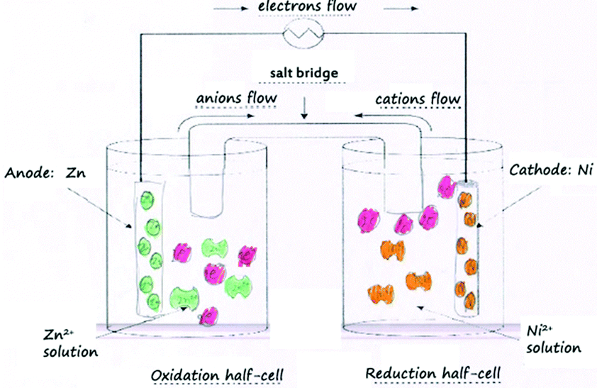

# Apartado b

A 25ºC
$$E^0=E_{cat}-E_{ani}=E_{Ni}^0-E_{Zn}^0=\\= -0.763\,V-(-0.25\,V)=0.513\,V$$

# Apartado c

Según la ecuación de Nernst, y sabiendo que las concentraciones son $[Zn^{2+}]=[Ni^{2+}]=1\,M$

$$E=E^{0}-2.303\cdot\frac{RT}{nF}\cdot log\left(\frac{[Zn^{2+}]}{[Ni^{2+}]}\right)\\=E^{0}-2.303\cdot\frac{RT}{nF}\cdot log\left(1\right)=E^{0}=0.513 \cdot V$$

En este caso, la temperatura no tiene influencia ninguna. $E_{40ºC}^0 = E^0=0.513 \cdot V$ , ya que el logaritmo de la unidad es cero.

# Apartado d

Por la misma razón que antes, aunque cambien las concentraciones, si son iguales, no cambia el potencial: $E^0=0.513 \cdot V$

# Apartado e: aplicando la ec. de Nernst

En este caso sí que justificamos el uso de la ecuación de Nernst.
$$E=E^{0}-2.303\cdot\frac{RT}{nF}\cdot log\left(\frac{[Zn^{2+}]}{[Cu^{2+}]}\right)=\\=E^{0}-2.303\cdot\frac{8.31\, J\cdot mol^{-1}\cdot K^{-1} \cdot 313\,K}{2 \cdot 9.65\times 10^{4}\,C/mol}\cdot log\left(2\right)=\\=0.513 \cdot V - 0.031 \cdot log(2) \cdot V = \boldsymbol{0.504\,V}$$